# SurvMeth 687 FA23 HW #1

Cheng, Chia Wen

2023-09-26

## Setup

```r
# set working direction to where the data set was stored locally
setwd("G:/My Drive/0. study abroad/academic/10. 2023 Fall/5. SurvMeth 687 Applications of Statistical Modeling/2. Homework/Homework 1")
# load required packages
library(lme4)
library(nlme)
library(lmerTest)
library(tidyverse)
library(dplyr)
library(haven) # for read_dta()
library(ggplot2)
library(RColorBrewer)
# read the data set from STATA data
growth <- read_dta('growth.dta')
# looking into data structure
str(growth) # subject is numeric; gender is character; age is numeric; distance is numeric; index is numeric; & largedist is numeric
```

```
## tibble [108 × 6] (S3: tbl_df/tbl/data.frame)
##  $ subject  : num [1:108] 1 1 1 1 2 2 2 2 3 3 ...
##   ..- attr(*, "label")= chr "subject"
##   ..- attr(*, "format.stata")= chr "%8.0g"
##  $ gender   : chr [1:108] "F" "F" "F" "F" ...
##   ..- attr(*, "label")= chr "gender"
##   ..- attr(*, "format.stata")= chr "%1s"
##  $ age      : num [1:108] 8 10 12 14 8 10 12 14 8 10 ...
##   ..- attr(*, "label")= chr "age in years"
##   ..- attr(*, "format.stata")= chr "%8.0g"
##  $ distance : num [1:108] 21 20 21.5 23 21 21.5 24 25.5 20.5 24 ...
##   ..- attr(*, "label")= chr "distance (mm) from center of pituitary to pteryo-maxillary fissure"
##   ..- attr(*, "format.stata")= chr "%9.0g"
##  $ index    : num [1:108] 1 1 1 1 2 2 2 2 3 3 ...
##   ..- attr(*, "format.stata")= chr "%8.0g"
##  $ largedist: num [1:108] 0 0 0 0 0 0 1 1 0 1 ...
##   ..- attr(*, "format.stata")= chr "%8.0g"
##  - attr(*, "label")= chr "growth dataset written by Stat/Transfer Ver. 16.3.1592.0705"
```

```r
typeof(growth) # dataset growth is a list
```

```
## [1] "list"
```

subject: numeric; subject ID number, indicate different children  
gender: character; child’s sex, where Male = M and Female = F  
age: numeric; age of child at measurement (8, 10, 12, 14)  
distance: numeric; distance from the center of the pituitary to the pteryo-maxillary fissure in mm; dependent variable of interest  
index: numeric; gender-specific ID variable  
largedist: numeric (should change to factor in model fitting because they’re classes); a binary indicator of larger than expected growth, larger = 1, no larger = 0

Currently, every variable is numeric except for gender. However, it doesn’t make sense to mark IDs as continuous numbers. Binary independent variable, largedist, should also be a classification variable. Thus, I will have to apply as.factor() for variable subject, index, and largedist when appropriate.

## 1. Describe the sample of children in a reasonable way, i.e., construct a table or a graph of descriptive statistics as you may do for a publication. Be sure to remember that there is more than one observation per child, and keep the study objectives in mind with your descriptive presentation. Comment briefly on the general patterns that you see in the descriptive statistics.

```r
# examine whether any columns contain NAs
apply(is.na(growth), 2, sum) # 2 indicates columns, to change to examine rows, use 1 instead
```

```
##   subject    gender       age  distance     index largedist
##         0         0         0         0         0         0
```

```r
# a. for independent variable gender
## I want to count the numbers of each gender
## so I created a new data frame with unique subjects
## and the corresponding data including genders
subject_distinct <- growth %>%
  distinct(subject, .keep_all = TRUE)
gender_counts <- subject_distinct %>%
  group_by(gender) %>%
  summarise(count = n())
gender_counts # there are 11 female and 16 male in our dataset
```

| gender | count |
| --- | --- |
| F | 11 |
| M | 16 |

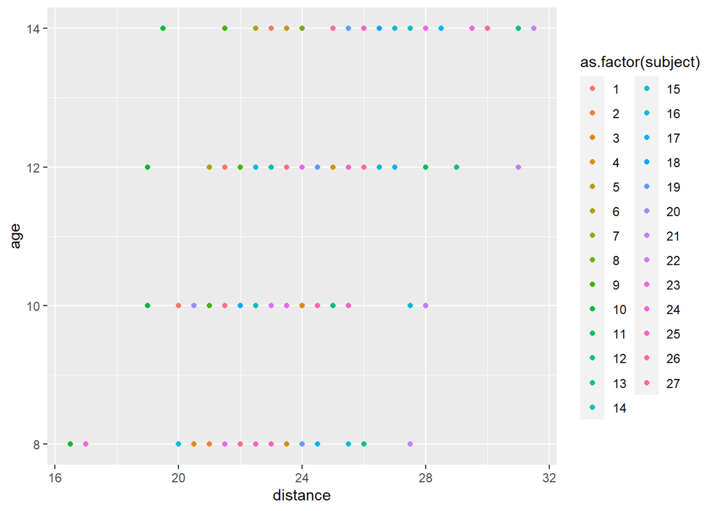

```r
# b. for dependent variable distance
## scatter plot: indicating the relationships between age and distance grouped by subject numbers
sp_plot <- ggplot(growth, aes(x = distance, y = age, group = as.factor(subject), color = as.factor(subject)))
sp_plot + geom_point()
```

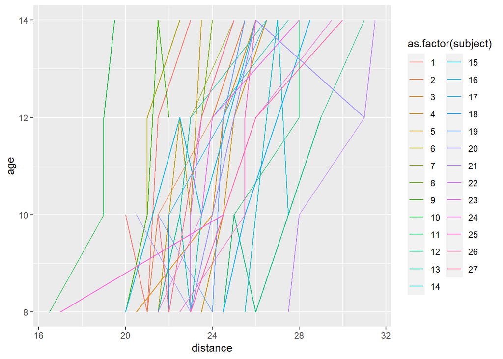

```r
sp_plot + geom_line()
```

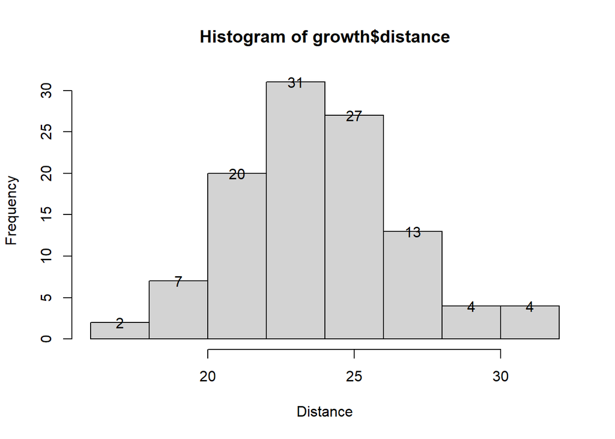

```r
## histogram: showing the distribution of distances across this sample
hist_dis <- hist(growth$distance, include.lowest = TRUE, xlab = "Distance")
text(hist_dis$mids, hist_dis$counts, labels = hist_dis$counts)
```

```r
## descriptive statistics
summary(growth$distance, useNA = 'always')
```

```
##    Min. 1st Qu.  Median    Mean 3rd Qu.    Max.
##   16.50   22.00   23.75   24.02   26.00   31.50
```

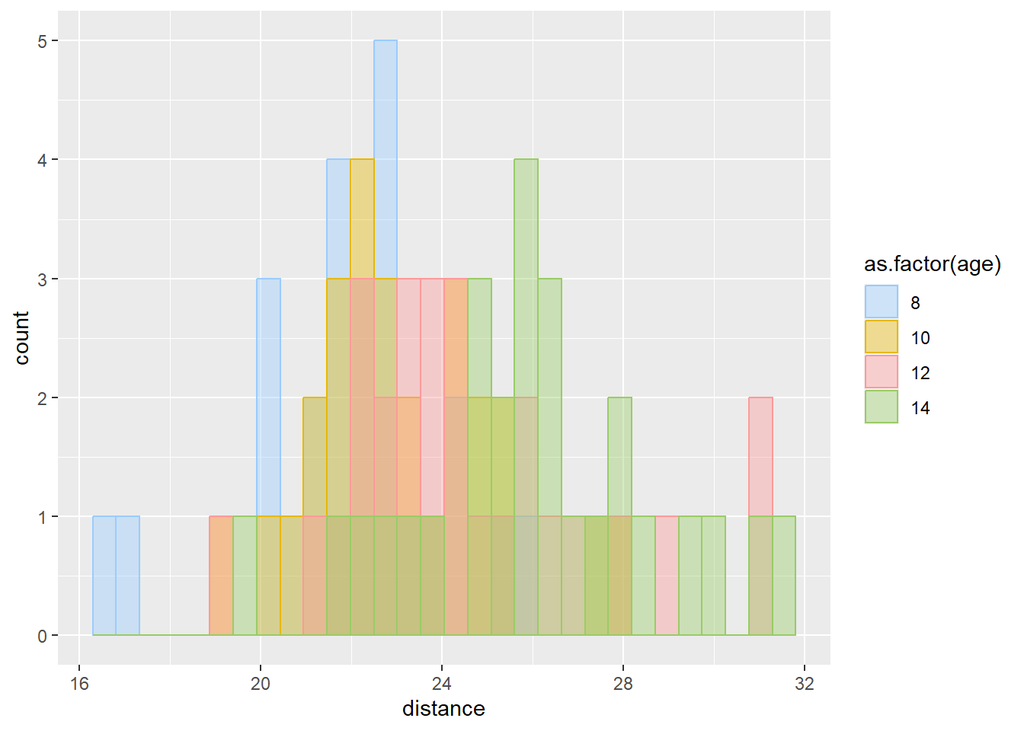

```r
## histogram distance by age: showing the distribution of distances across this sample grouped by age
ggplot(growth, aes(x = distance)) +
  geom_histogram(aes(color = as.factor(age), fill = as.factor(age)), position = "identity", alpha = 0.4) +
  scale_color_manual(values = c("#99CCFF", "#E7B800", "#FF9999", "#99CC66")) +
  scale_fill_manual(values = c("#99CCFF", "#E7B800", "#FF9999", "#99CC66"))
```

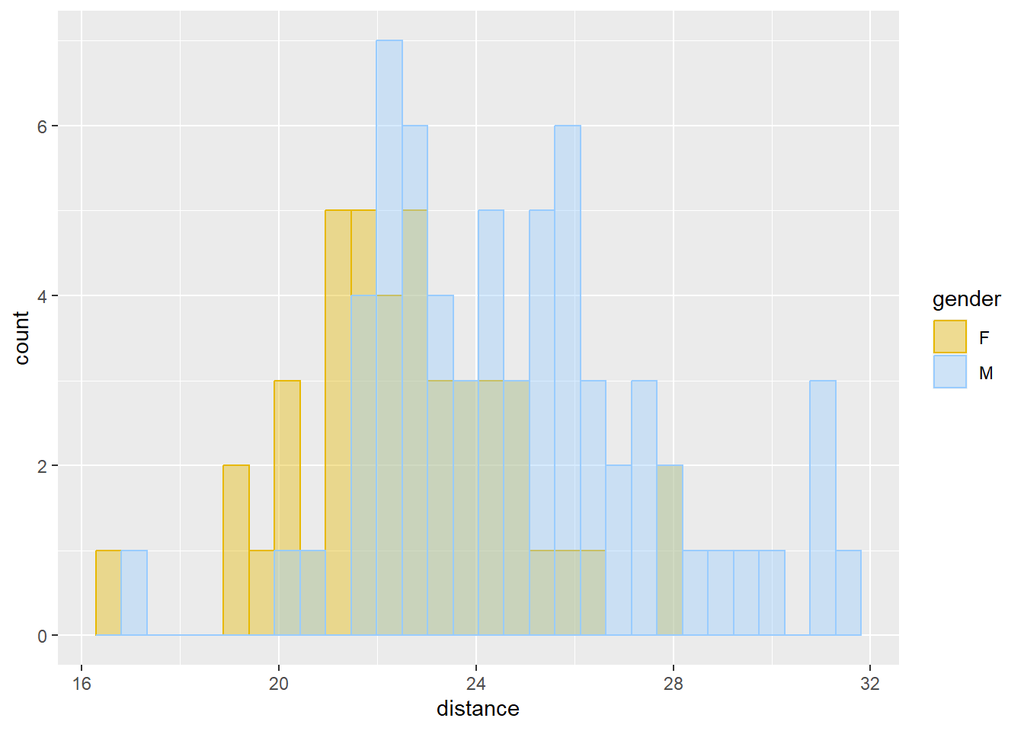

```r
## histogram distance by gender: showing the distribution of distances across this sample grouped by gender
ggplot(growth, aes(x = distance)) +
  geom_histogram(aes(color = gender, fill = gender), position = "identity", alpha = 0.4) +
  scale_color_manual(values = c("#E7B800", "#99CCFF")) +
  scale_fill_manual(values = c("#E7B800", "#99CCFF"))
```

```r
## boxplot disatnce by gender:
growth1 <- growth
growth1$gender[growth$gender == "F"] <- 1
growth1$gender[growth$gender == "M"] <- 0
str(growth1)
```

```
## tibble [108 × 6] (S3: tbl_df/tbl/data.frame)
##  $ subject  : num [1:108] 1 1 1 1 2 2 2 2 3 3 ...
##   ..- attr(*, "label")= chr "subject"
##   ..- attr(*, "format.stata")= chr "%8.0g"
##  $ gender   : chr [1:108] "1" "1" "1" "1" ...
##   ..- attr(*, "label")= chr "gender"
##   ..- attr(*, "format.stata")= chr "%1s"
##  $ age      : num [1:108] 8 10 12 14 8 10 12 14 8 10 ...
##   ..- attr(*, "label")= chr "age in years"
##   ..- attr(*, "format.stata")= chr "%8.0g"
##  $ distance : num [1:108] 21 20 21.5 23 21 21.5 24 25.5 20.5 24 ...
##   ..- attr(*, "label")= chr "distance (mm) from center of pituitary to pteryo-maxillary fissure"
##   ..- attr(*, "format.stata")= chr "%9.0g"
##  $ index    : num [1:108] 1 1 1 1 2 2 2 2 3 3 ...
##   ..- attr(*, "format.stata")= chr "%8.0g"
##  $ largedist: num [1:108] 0 0 0 0 0 0 1 1 0 1 ...
##   ..- attr(*, "format.stata")= chr "%8.0g"
##  - attr(*, "label")= chr "growth dataset written by Stat/Transfer Ver. 16.3.1592.0705"
```

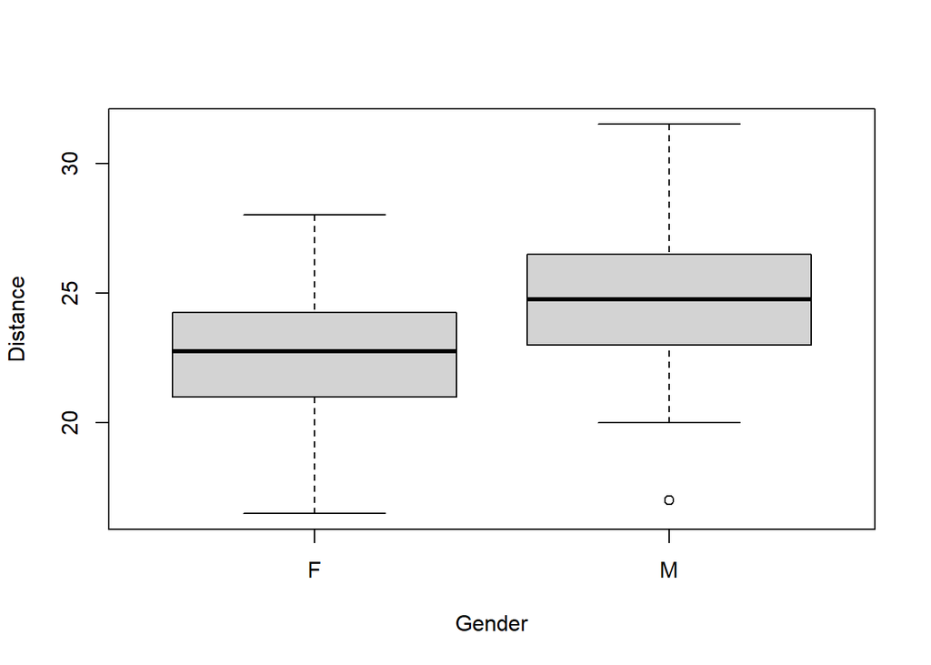

```r
plot(distance ~ factor(gender),
     data = growth,
     xlab = "Gender",
     ylab = "Distance")
```

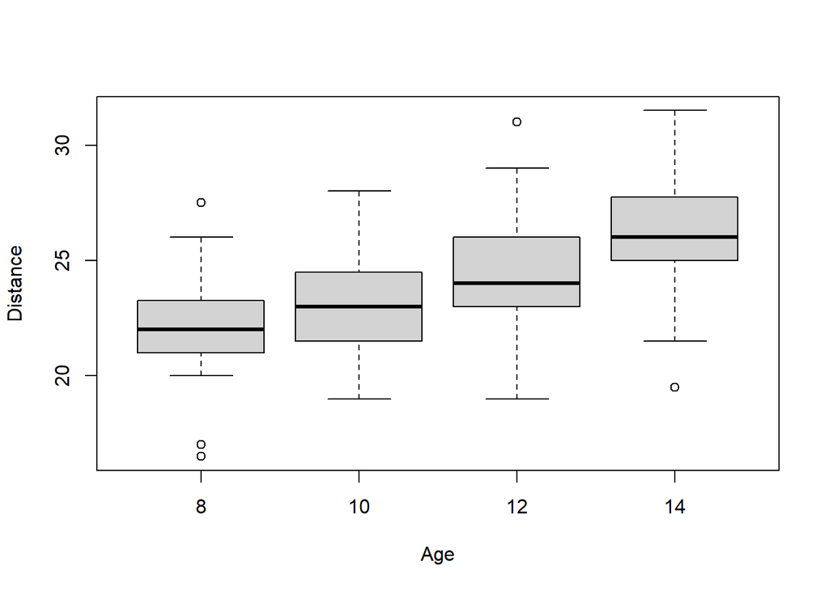

```r
## boxplot disatnce by age:
plot(distance ~ factor(age),
     data = growth,
     xlab = "Age",
     ylab = "Distance")
```

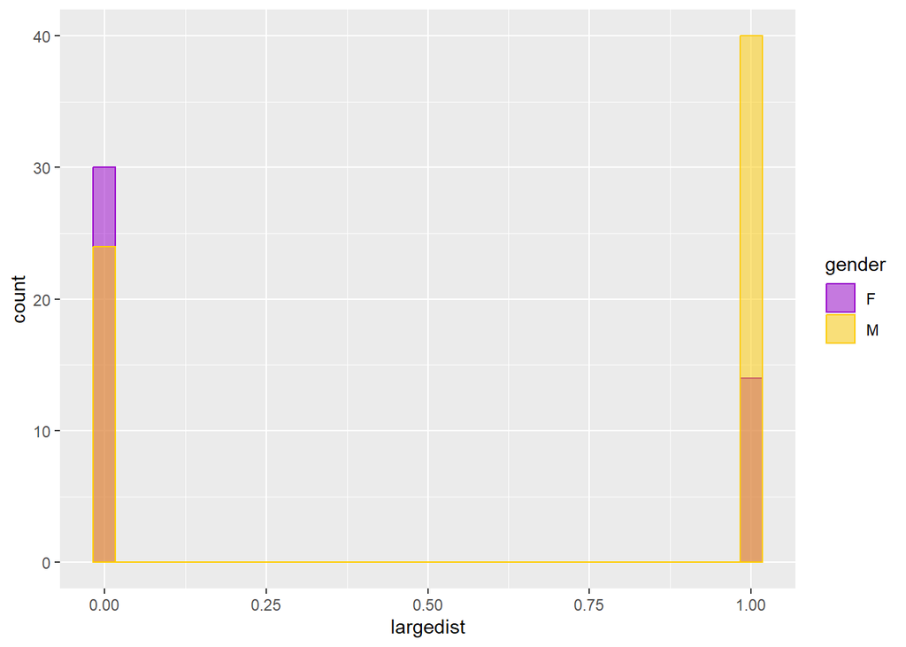

```r
# c. for independent variable largedist
## histogram largedist by gender: showing the distribution of largedist across this sample grouped by gender
ggplot(growth, aes(x = largedist)) +
  geom_histogram(aes(color = gender, fill = gender), position = "identity", alpha = 0.5) +
  scale_color_manual(values = c("#9900CC", "#FFCC00")) +
  scale_fill_manual(values = c("#9900CC", "#FFCC00"))
```

## 2. Fit an initial multilevel model to the DISTANCE dependent variable, including a fixed intercept and a fixed effect of AGE (i.e., assuming a linear relationship), a random effect associated with the intercept for each child, and a random effect associated with AGE for each child. Include the estimated covariance of the two random effects in your model. Generate a custom table presenting all of the parameter estimates, their standard errors, and any significance tests automatically generated by the procedure you are using.

```r
# a. fit an initial multilevel model with a fixed intercept, a fixed effect of age, a random effect associated with the intercept, and a random effect associated with age for each child
growth["age_recenter"] = growth$age - 8
mod_ini = lmer(distance ~ age_recenter + (age_recenter|subject), REML = T, data = growth)
mod_ini
```

```
## Linear mixed model fit by REML ['lmerModLmerTest']
## Formula: distance ~ age_recenter + (age_recenter | subject)
##    Data: growth
## REML criterion at convergence: 442.6367
## Random effects:
##  Groups   Name         Std.Dev. Corr
##  subject  (Intercept)  1.8866
##           age_recenter 0.2264   0.21
##  Residual              1.3100
## Number of obs: 108, groups:  subject, 27
## Fixed Effects:
##  (Intercept)  age_recenter
##      22.0426        0.6602
```

```r
sum_mod_ini <- summary(mod_ini)
sum_mod_ini
```

```
## Linear mixed model fit by REML. t-tests use Satterthwaite's method [
## lmerModLmerTest]
## Formula: distance ~ age_recenter + (age_recenter | subject)
##    Data: growth
##
## REML criterion at convergence: 442.6
##
## Scaled residuals:
##     Min      1Q  Median      3Q     Max
## -3.2231 -0.4938  0.0073  0.4721  3.9160
##
## Random effects:
##  Groups   Name         Variance Std.Dev. Corr
##  subject  (Intercept)  3.55939  1.8866
##           age_recenter 0.05127  0.2264   0.21
##  Residual              1.71621  1.3100
## Number of obs: 108, groups:  subject, 27
##
## Fixed effects:
##              Estimate Std. Error       df t value Pr(>|t|)
## (Intercept)  22.04259    0.41991 25.99990  52.494  < 2e-16 ***
## age_recenter  0.66019    0.07125 25.99986   9.265 1.01e-09 ***
## ---
## Signif. codes:  0 '***' 0.001 '**' 0.01 '*' 0.05 '.' 0.1 ' ' 1
##
## Correlation of Fixed Effects:
##             (Intr)
## age_recentr -0.208
```

```r
# b. extract estimated covariance of the two random effects
sum_mod_ini$varcor[["subject"]]
```

```
##              (Intercept) age_recenter
## (Intercept)   3.55939149   0.08908879
## age_recenter  0.08908879   0.05126886
## attr(,"stddev")
##  (Intercept) age_recenter
##    1.8866350    0.2264263
## attr(,"correlation")
##              (Intercept) age_recenter
## (Intercept)    1.0000000    0.2085491
## age_recenter   0.2085491    1.0000000
```

```r
# c. create a custom table storing all parameter estimates, their standard errors, and any significance tests automatically generated by the algorithm
data.frame(sum_mod_ini$coefficients, "Random Effect Variance" = c(sum_mod_ini$varcor[["subject"]][1], sum_mod_ini$varcor[["subject"]][4]))
```

|  | Estimate | Std..Error | df | t.value | Pr...t.. | Random.Effect.Variance |
| --- | --- | --- | --- | --- | --- | --- |
| (Intercept) | 22.0425926 | 0.41990898 | 25.99990 | 52.493739 | 6.472721e-28 | 3.55939149 |
| age_recenter | 0.6601852 | 0.07125312 | 25.99986 | 9.265352 | 1.013246e-09 | 0.05126886 |

## 3. Interpret the model parameters estimated in part 2, including the estimated variance components. Frame your interpretations with respect to addressing the two research objectives.

I re-centered variable age so that the intercept will represent 8-year-old kids. The model with the five estimated parameters is specified as
$$y_{ij}=\beta_0+\beta_1age_{ij}+\mu_{0j}+\mu_{1j}age_{ij}+e_{ij}$$
where j is referred to as each distinct subject and i is each row, representing ages of subjects, in the dataset
$$y_{ij}=22.0426+0.6602age_{ij}+\mu_{0j}+\mu_{1j}age_{ij}+e_{ij}$$
1. The estimated mean of distance of cranial is $\hat{\beta}_0= 22.0426$ (millimeter), holding all other factors constant. With a p-value smaller than 0.05, we reject the null hypothesis that the mean distance of cranial is zero.
2. The estimated average of cranial growth (difference of distance) across ages is $\hat{\beta_1}= 0.6602$ (millimeter), holding all other factors constant. With a p-value smaller than 0.05, we reject the null hypothesis that the average growth distance of cranial across ages is zero.
3. The estimated variance of the random child effects is
$\hat{\sigma}_0^2 = 3.5594$.
4. The estimated variance of the random age effects is $\hat{\sigma}^2 = 0.0513$.
5. The estimated residual variance is 1.7162.
$$e_{ij}\sim N(0, 1.7162)$$
6. The estimated intra-subject correlation (or ICC) is $\hat{\rho} = 3.5594/(3.5594 + 0.0513 + 1.7162)= 0.6682$. A large proportion of the differences is explained by different subjects and the growth pattern remains similar within each kid.
7. The estimated correlation between the two random effects, age and the intercept, is 0.21, a weak positive correlation indicating that when age increases, the difference of the distance also increases across subjects.
8. The estimated covariance of the two random effects is 0.0891.
$$\left(
\begin{array}{c}
\mu_{0j}\\
\mu_{1j}
\end{array} \right) \sim N\left(
\left(
\begin{array}{c}
0\\
0
\end{array} \right),
\left(
\begin{array}{cc}
3.5594&0.0891\\\
0.0891&0.0513
\end{array} \right) \equiv D
\right)$$

## 4. Test the null hypothesis that the variance of the random AGE effects is equal to zero using a likelihood ratio test. What is the conclusion of this test, again with respect to the research objectives?

```r
mod_4 = lmer(distance ~ age_recenter + (1|subject), REML = T, data = growth)
mod_4
```

```
## Linear mixed model fit by REML ['lmerModLmerTest']
## Formula: distance ~ age_recenter + (1 | subject)
##    Data: growth
## REML criterion at convergence: 447.0025
## Random effects:
##  Groups   Name        Std.Dev.
##  subject  (Intercept) 2.115
##  Residual             1.432
## Number of obs: 108, groups:  subject, 27
## Fixed Effects:
##  (Intercept)  age_recenter
##      22.0426        0.6602
```

```r
# Function to calculate LRT p-values for variances of random effects
lrt.pvalue <- function(fit1, fit2) {
  lrtstat <-
    (-2 * as.numeric(summary(fit2)$logLik)) - (-2 * as.numeric(summary(fit1)$logLik))
  pvalue = 0.5 * (1 - pchisq(lrtstat, 2)) + 0.5 * (1 - pchisq(lrtstat, 1))
  return(pvalue)
}
lrt.pvalue(mod_ini, mod_4)
```

```
## [1] 0.07468957
```

With a p-value of 0.0747, which is greater than 0.05, we fail to reject our null hypothesis that the random age effects is equal to zero. Thus, we are not able to exclude the conclusion that cranial growth of children across age 8-14 have similar differences at different ages as the starting points (i.e., the differences between age 8-10, 10-12, and 12-14 within a kid have a linear relationship).

## 5. Briefly outline how one would perform a similar test of the covariance between the two random effects. You do not need to actually perform this test.

We performed a likelihood ratio test to compare the covariance between the two random effects. Alternatively, one can also compare covariance between the two random effects using an Adaptive Gaussian Quadrature (AGQ) to approximate the likelihood, a Laplace Approximation, or a pseudo-likelihood / penalized quasi-likelihood estimation.

## 6. Add the fixed effects necessary to address the second research objective, i.e., determine whether child GENDER explains variability in the linear age effects across children. What percentage of the variance in the random effects of AGE is explained by adding these fixed effects? Clearly interpret all of the fixed effects estimated in this expanded model.

```r
mod_add = lmer(distance ~ age_recenter * gender + (age_recenter|subject), REML = T, data = growth)
mod_add
```

```
## Linear mixed model fit by REML ['lmerModLmerTest']
## Formula: distance ~ age_recenter * gender + (age_recenter | subject)
##    Data: growth
## REML criterion at convergence: 432.5817
## Random effects:
##  Groups   Name         Std.Dev. Corr
##  subject  (Intercept)  1.7983
##           age_recenter 0.1803   -0.09
##  Residual              1.3100
## Number of obs: 108, groups:  subject, 27
## Fixed Effects:
##          (Intercept)          age_recenter               genderM
##              21.2091                0.4795                1.4065
## age_recenter:genderM
##               0.3048
```

```r
summary(mod_add)
```

```
## Linear mixed model fit by REML. t-tests use Satterthwaite's method [
## lmerModLmerTest]
## Formula: distance ~ age_recenter * gender + (age_recenter | subject)
##    Data: growth
##
## REML criterion at convergence: 432.6
##
## Scaled residuals:
##     Min      1Q  Median      3Q     Max
## -3.1681 -0.3859  0.0071  0.4452  3.8495
##
## Random effects:
##  Groups   Name         Variance Std.Dev. Corr
##  subject  (Intercept)  3.23394  1.7983
##           age_recenter 0.03252  0.1803   -0.09
##  Residual              1.71621  1.3100
## Number of obs: 108, groups:  subject, 27
##
## Fixed effects:
##                      Estimate Std. Error      df t value Pr(>|t|)
## (Intercept)           21.2091     0.6350 25.0001  33.401  < 2e-16 ***
## age_recenter           0.4795     0.1037 25.0001   4.623 9.89e-05 ***
## genderM                1.4065     0.8249 25.0001   1.705   0.1006
## age_recenter:genderM   0.3048     0.1347 25.0001   2.262   0.0326 *
## ---
## Signif. codes:  0 '***' 0.001 '**' 0.01 '*' 0.05 '.' 0.1 ' ' 1
##
## Correlation of Fixed Effects:
##             (Intr) ag_rcn gendrM
## age_recentr -0.396
## genderM     -0.770  0.305
## ag_rcntr:gM  0.305 -0.770 -0.396
```

```r
# extract covariance matrix
summary(mod_add)$varcor[["subject"]]
```

```
##              (Intercept) age_recenter
## (Intercept)    3.2339420  -0.02942840
## age_recenter  -0.0294284   0.03252413
## attr(,"stddev")
##  (Intercept) age_recenter
##    1.7983164    0.1803445
## attr(,"correlation")
##              (Intercept) age_recenter
## (Intercept)   1.00000000  -0.09073977
## age_recenter -0.09073977   1.00000000
```

```r
# calculate the percentage of variance explained
1 - (summary(mod_add)$varcor[["subject"]][4] / summary(mod_add)$varcor[["subject"]][1])
```

```
## [1] 0.9899429
```

## 7. Refit the model from part 2, only treating AGE as a categorical predictor rather than a continuous predictor. What advantage does this approach offer? When including fixed effects of the categories of age, can we also allow the age effects to randomly vary across children, as in the initial model? Why or why not?

```r
mod_mod = lmer(distance ~ factor(age) + (age_recenter|subject), REML = T, data = growth)
mod_mod
```

```
## Linear mixed model fit by REML ['lmerModLmerTest']
## Formula: distance ~ factor(age) + (age_recenter | subject)
##    Data: growth
## REML criterion at convergence: 439.0123
## Random effects:
##  Groups   Name         Std.Dev. Corr
##  subject  (Intercept)  1.881
##           age_recenter 0.223    0.22
##  Residual              1.322
## Number of obs: 108, groups:  subject, 27
## Fixed Effects:
##   (Intercept)  factor(age)10  factor(age)12  factor(age)14
##       22.1852         0.9815         2.4630         3.9074
```

```r
summary(mod_mod)
```

```
## Linear mixed model fit by REML. t-tests use Satterthwaite's method [
## lmerModLmerTest]
## Formula: distance ~ factor(age) + (age_recenter | subject)
##    Data: growth
##
## REML criterion at convergence: 439
##
## Scaled residuals:
##     Min      1Q  Median      3Q     Max
## -3.3408 -0.4663  0.0255  0.4218  3.9112
##
## Random effects:
##  Groups   Name         Variance Std.Dev. Corr
##  subject  (Intercept)  3.53779  1.881
##           age_recenter 0.04973  0.223    0.22
##  Residual              1.74692  1.322
## Number of obs: 108, groups:  subject, 27
##
## Fixed effects:
##               Estimate Std. Error      df t value Pr(>|t|)
## (Intercept)    22.1852     0.4424 31.8472  50.146  < 2e-16 ***
## factor(age)10   0.9815     0.3698 67.6042   2.654  0.00991 **
## factor(age)12   2.4630     0.3986 68.2700   6.179 4.07e-08 ***
## factor(age)14   3.9074     0.4424 29.7375   8.832 8.19e-10 ***
## ---
## Signif. codes:  0 '***' 0.001 '**' 0.01 '*' 0.05 '.' 0.1 ' ' 1
##
## Correlation of Fixed Effects:
##             (Intr) fc()10 fc()12
## factor(g)10 -0.353
## factor(g)12 -0.288  0.539
## factor(g)14 -0.224  0.531  0.618
```

```r
summary(mod_mod)$varcor[["subject"]]
```

```
##              (Intercept) age_recenter
## (Intercept)   3.53779057   0.09370798
## age_recenter  0.09370798   0.04973242
## attr(,"stddev")
##  (Intercept) age_recenter
##    1.8809015    0.2230077
## attr(,"correlation")
##              (Intercept) age_recenter
## (Intercept)    1.0000000    0.2234039
## age_recenter   0.2234039    1.0000000
```

Converting *age* from continuous variable to categorical allows us to distinguish the means of children’s cranial distances at different ages. In the output, there are three values indicating the differences between age 8, which is the intercept, and the other ages in the data we collected. Visualizing the intercepts, there will be four starting points at 22.1852 mm, 23.1667 mm, 24.6482 mm, and 26.0926 mm. We cannot allow the age effects to randomly vary across children as in the initial model because random effects are usually used for continuous predictors to capture unobserved heterogeneity across levels. However, variations in the effects of age across children can be accounted for by including interaction terms.

## 8. After deciding whether to include the random age effects in part 7, interpret the parameter estimates from the model fitted in part 7 (and the variance components).

The model with the estimated parameters is specified as
$$y_{ij}=\beta_0+\beta_1age_{10,
j}+\beta_2age_{12, j}+\beta_3age_{14,
j}+\mu_{0j}+\mu_{1j}age_{ij}+e_{ij}$$
where j is referred to as each subject (row) in the dataset and i is each distinct age
$$y_{ij}=22.1852+0.9815age_{10,
j}+2.4630age_{12, j}+3.9074age_{14,
j}+\mu_{0j}+\mu_{1j}age_{ij}+e_{ij}$$
1. The estimated mean distance of cranial for child at age 8 is $\hat{\beta}_0= 22.1852$ (millimeter), holding all other factors constant. With a p-value smaller than 0.05, we reject the null hypothesis that the mean distance of cranial at age 8 is zero.
2. The estimated mean distance of cranial for child at age 10 is 23.1667 and $\hat{\beta}_1= 0.9815$ (millimeter), holding all other factors constant. With a p-value smaller than 0.05, we reject the null hypothesis that the mean distance of cranial at age 10 is zero.
3. The estimated mean distance of cranial for child at age 12 is 24.6482 and $\hat{\beta}_2= 2.4630$ (millimeter), holding all other factors constant. With a p-value smaller than 0.05, we reject the null hypothesis that the mean distance of cranial at age 12 is zero.
4. The estimated mean distance of cranial for child at age 14 is 26.0926 and $\hat{\beta}_3= 3.9074$ (millimeter), holding all other factors constant. With a p-value smaller than 0.05, we reject the null hypothesis that the mean distance of cranial at age 14 is zero.
5. The estimated variance of the random child effects is
$\hat{\sigma}_0^2 = 3.5378$.
4. The estimated variance of the random age effects is $\hat{\sigma}^2 = 0.0497$.
5. The estimated residual variance is
$$e_{ij}\sim N(0, 1.747)$$
.
6. The estimated intra-subject correlation (or ICC) is $\hat{\rho} = 3.5378/(3.5378+0.0497+1.747)= 0.6632$. A large proportion of the differences is explained by different subjects and the growth pattern remains similar within each kid across ages.
7. The estimated correlation between the two random effects, age and the intercept, is 0.22, a weak positive correlation indicating that when age increases, the difference of the distance also increases.
8. The estimated covariance of the two random effects is 0.0937.
$$\left(
\begin{array}{c}
\mu_{0j}\\
\mu_{1j}
\end{array} \right) \sim N\left(
\left(
\begin{array}{c}
0\\
0
\end{array} \right),
\left(
\begin{array}{cc}
3.5378&0.0937\\\
0.0937&0.0497
\end{array} \right) \equiv D
\right)$$

## 9. Which model (part 2 or part 7) appears to have a better fit? Make use of some simple model diagnostics to help justify your choice.

```r
AIC(mod_ini)
```

```
## [1] 454.6367
```

```r
AIC(mod_mod)
```

```
## [1] 455.0123
```

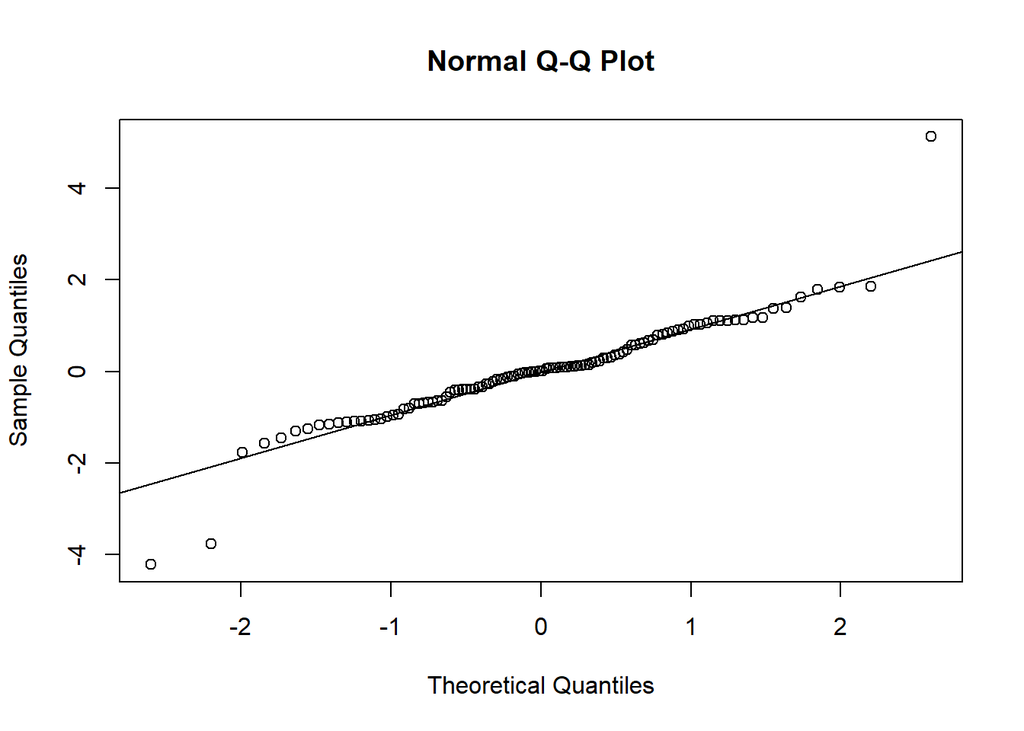

```r
# diagnostic
## mod_ini
qqnorm(resid(mod_ini))
qqline(resid(mod_ini))
```

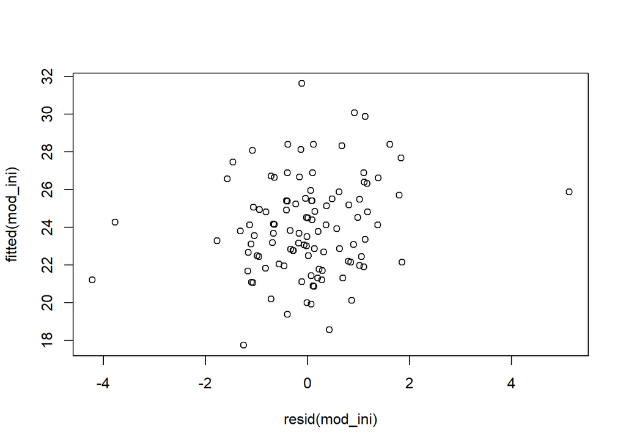

```r
plot(resid(mod_ini), fitted(mod_ini))
```

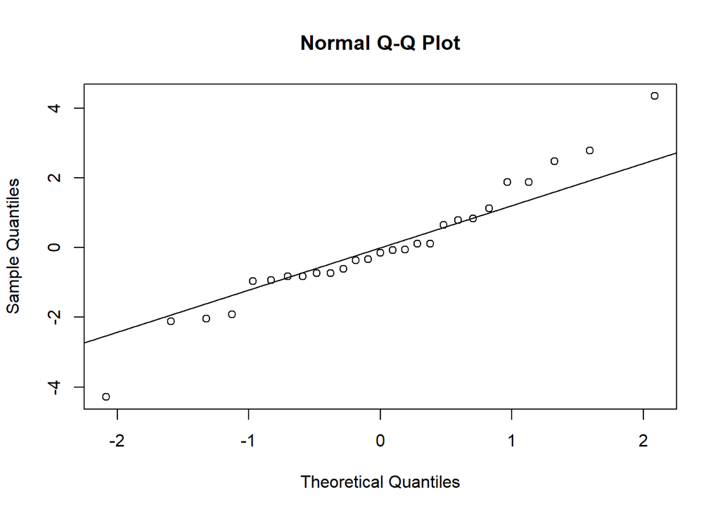

```r
## intercept
qqnorm(ranef(mod_ini)$subject[, 1])
qqline(ranef(mod_ini)$subject[, 1])
```

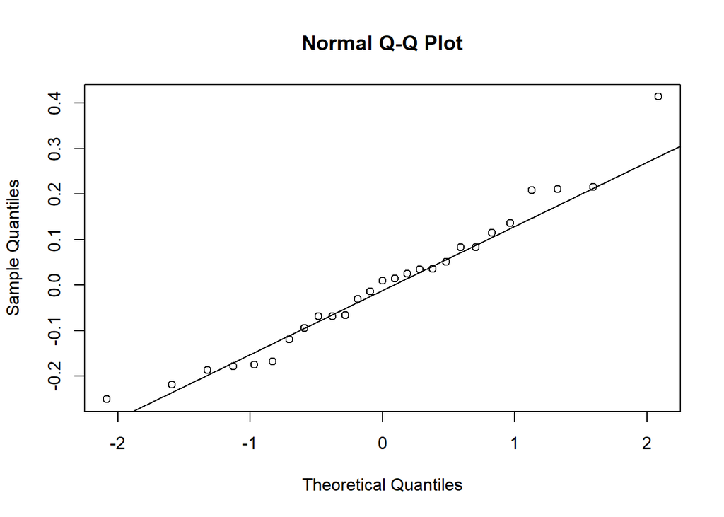

```r
## slopes
qqnorm(ranef(mod_ini)$subject[, 2])
qqline(ranef(mod_ini)$subject[, 2])
```

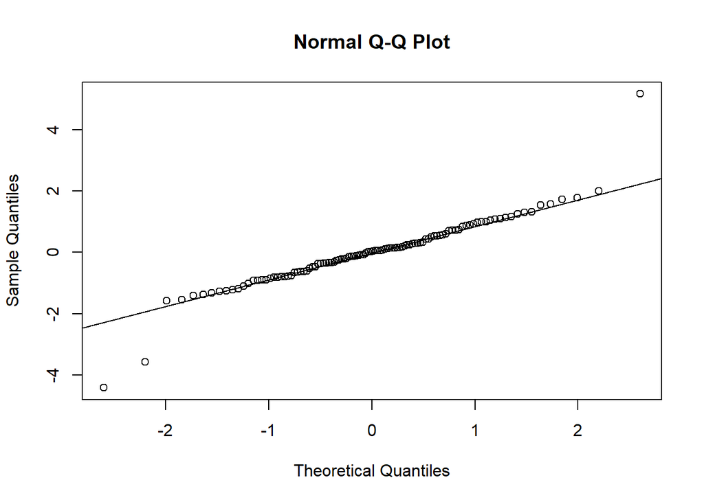

```r
## mod_mod
qqnorm(resid(mod_mod))
qqline(resid(mod_mod))
```

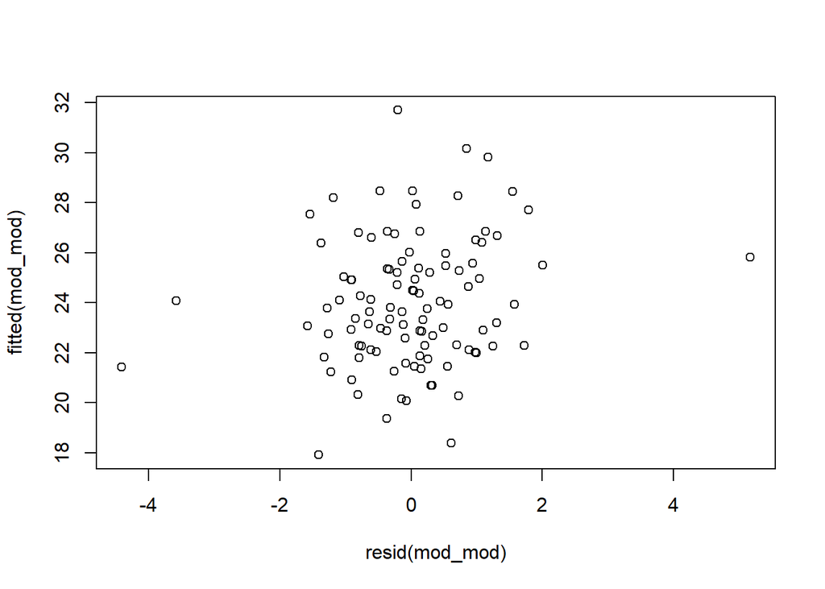

```r
plot(resid(mod_mod), fitted(mod_mod))
```

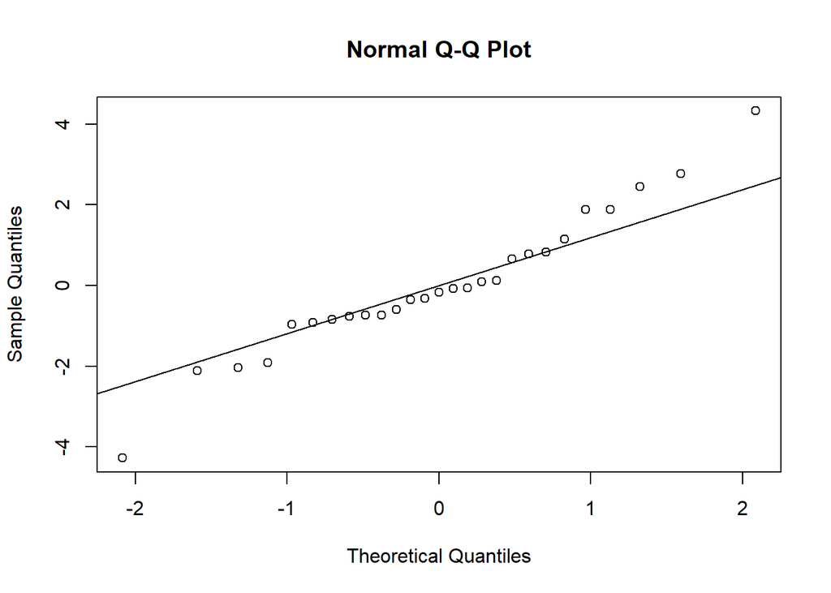

```r
## intercept
qqnorm(ranef(mod_mod)$subject[, 1])
qqline(ranef(mod_mod)$subject[, 1])
```

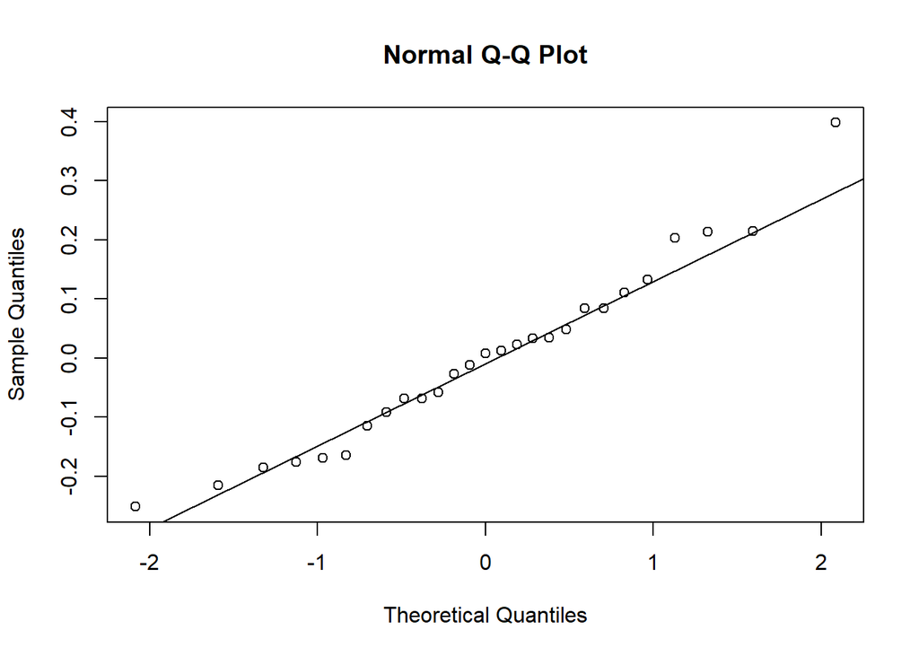

```r
## slopes
qqnorm(ranef(mod_mod)$subject[, 2])
qqline(ranef(mod_mod)$subject[, 2])
```

From the AIC, the initial model I built in part 2 has a smaller value and can be concluded to have a better fit from this process. From the diagnostic from q-q plots, the residuals look normally distributed but with a few outliers. In addition, there seems to be no correlation between the fitted values and the residuals in the initial model (in part 2). Both plots of the EBLUPs for each random subject effect based on the random coefficient model look good except for about 1~2 outlier(s). The diagnostics of the two models are very similar.